Skip to contents

# The VetResearchLMM application

Muhammad Yaseen

2026-11-10

Source: [`vignettes/VetResearchLMM_06_app.qmd`](https://github.com/myaseen208/VetResearchLMM/blob/HEAD/vignettes/VetResearchLMM_06_app.qmd)

## 1 Abstract

`vlm_app()` opens a point-and-click application in the web browser. It needs the packages **shiny**, **bslib** and **DT**. Every example of the book loads with one click, and every result comes with a plain-language interpretation, the printed output, tables to copy or download, plots and the R code that repeats the analysis.

```r
vlm_app(
    launch.browser = TRUE
  )
```

## 2 Pages

- **Data**: the ten data sets of the book or a CSV file.
- **Model**: fixed effects, random variance components, random coefficients per subject, a residual structure, estimation method, denominator degrees of freedom and test type. *Load an example of the book* fills every field for one of the 17 analyses of the book.
- **Means**: least-squares means and their differences with Tukey, Bonferroni or Sidak adjustment.
- **Estimates**: estimates and contrasts typed as in SAS, one per line, for example `Samorin mean: intercept 1 Drug 0 1 dose 0.5 0.5 Drug:dose 0 0 0.5 0.5`.
- **Random effects**: best linear unbiased predictions.
- **Expected mean squares**: the analysis of variance of PROC GLM with a RANDOM statement.
- **Compare**: independent, compound symmetry, AR(1) and random coefficient structures for the fixed effects of the Model page.

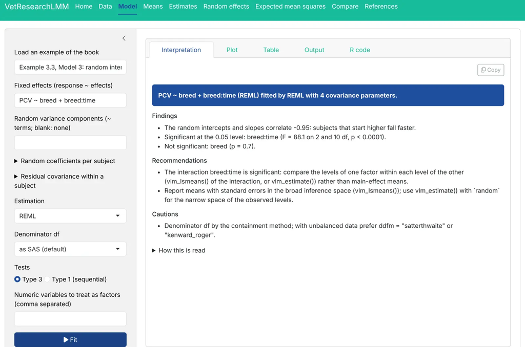

Figure 1: The Model page with Example 3.3, Model 3.

[figure not shown]

Figure 2: The Means page with Tukey-Kramer comparisons.

## 3 Deployment

`vlm_app_object()` returns the application object, for example for a file `app.R` on a server: `library(VetResearchLMM); vlm_app_object()`.